# RSocialScience

Jan-Philipp Kolb

22 Juni 2017

# Einführung und Motivation

# Pluspunkte von R

- Als Weg kreativ zu sein …
- Graphiken, Graphiken, Graphiken
- In Kombination mit anderen Programmen nutzbar
- Zur Verbindung von Datenstrukturen
- Zum Automatisieren
- Um die Intelligenz anderer Leute zu nutzen ;-)
- …

# Gründe

- R ist [frei verfügbar](https://www.r-project.org/). Es kann umsonst [runtergeladen](http://www.inside-r.org/why-use-r) werden.
- R ist eine Skriptsprache
- Gute Möglichkeiten für die [Visualisierung](http://www.sr.bham.ac.uk/~ajrs/R/r-gallery.html)
- R wird immer [populärer](https://twitter.com/josiahjdavis/status/559778930476220418)
- [Popularität von R](http://blog.revolutionanalytics.com/popularity/) ist in vielen Bereichen sehr hoch.

[figure not shown]

# [Warum R?](http://stats.idre.ucla.edu/r/seminars/intro/)

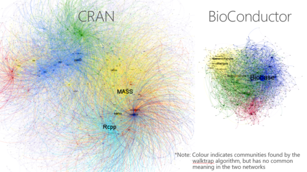

Modularer Aufbau

# [Viel genutzte Pakete](https://gallery.shinyapps.io/cran-gauge/)

[figure not shown]

# Dateien herunterladen

- Begleitend zu den Folien wird meistens auch ein R-File angeboten.
- Hier können Sie entweder das gesamte R-File herunterladen und in R ausführen oder einzelne Befehle per Copy/Paste übernehmen.
- Vereinzelt sind auch Datensätze vorhanden.
- `.csv` Dateien können direkt von R eingelesen werden (wie das geht werde ich noch zeigen).
- Wenn die `.csv` Dateien heruntergeladen werden sollen auch den Raw Button verwenden.
- Alle anderen Dateien (bspw. `.RData`) auch mittels Raw Button herunterladen.
- Informationen ausdrucken
- Zum Ausdrucken eignen sich die pdf-Dateien besser.
- Diese können mit dem Raw Button heruntergeladen werden.

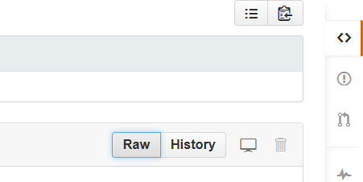

Raw Button zum Download

Wen Github näher interessiert:

- [Hello World](https://guides.github.com/activities/hello-world/)
- [Understanding the GitHub flow](https://guides.github.com/introduction/flow/)

# Basis R …

- Wenn man nur R herunterlädt und installiert, sieht das so aus:

[figure not shown]

- So habe ich bis 2012 mit R gearbeitet.

# … und Rstudio

# Erste Schritte mit R

# R ist eine Objekt-orientierte Sprache

Vektoren und Zuweisungen

- R ist eine Objekt-orientierte Sprache
- `<-` ist der Zuweisungsoperator

```r
b <- c(1,2) # erzeugt ein Objekt mit den Zahlen 1 und 2
```

- Eine Funktion kann auf dieses Objekt angewendet werden:

```r
mean(b) # berechnet den Mittelwert
```

```
## [1] 1.5
```

Mit den folgenden Funktionen können wir etwas über die Eigenschaften des Objekts lernen:

```r
length(b) # b hat die Länge 2
```

```
## [1] 2
```

# Objektstruktur

```r
str(b) # b ist ein numerischer Vektor
```

```
##  num [1:2] 1 2
```

# Funktionen im base-Paket

| Funktion | Bedeutung | Beispiel |
| --- | --- | --- |
| length() | Länge | length(b) |
| max() | Maximum | max(b) |
| min() | Minimum | min(b) |
| sd() | Standardabweichung | sd(b) |
| var() | Varianz | var(b) |
| mean() | Mittelwert | mean(b) |
| median() | Median | median(b) |

Diese Funktionen brauchen nur ein Argument.

# Funktionen mit mehr Argumenten

Andere Funktionen brauchen mehr:

| Argument | Bedeutung | Beispiel |
| --- | --- | --- |
| quantile() | 90 % Quantile | quantile(b,.9) |
| sample() | Stichprobe ziehen | sample(b,1) |

# Beispiel - Funktionen mit einem Argument

```r
max(b)
```

```
## [1] 2
```

```r
min(b)
```

```
## [1] 1
```

```r
sd(b)
```

```
## [1] 0.7071068
```

```r
var(b)
```

```
## [1] 0.5
```

# Funktionen mit einem Argument

```r
mean(b)
```

```
## [1] 1.5
```

```r
median(b)
```

```
## [1] 1.5
```

# Funktionen mit mehr Argumenten

```r
quantile(b,.9)
```

```
## 90%
## 1.9
```

```r
sample(b,1)
```

```
## [1] 1
```

# [Übersicht Befehle](http://cran.r-project.org/doc/manuals/R-intro.html)

http://cran.r-project.org/doc/manuals/R-intro.html

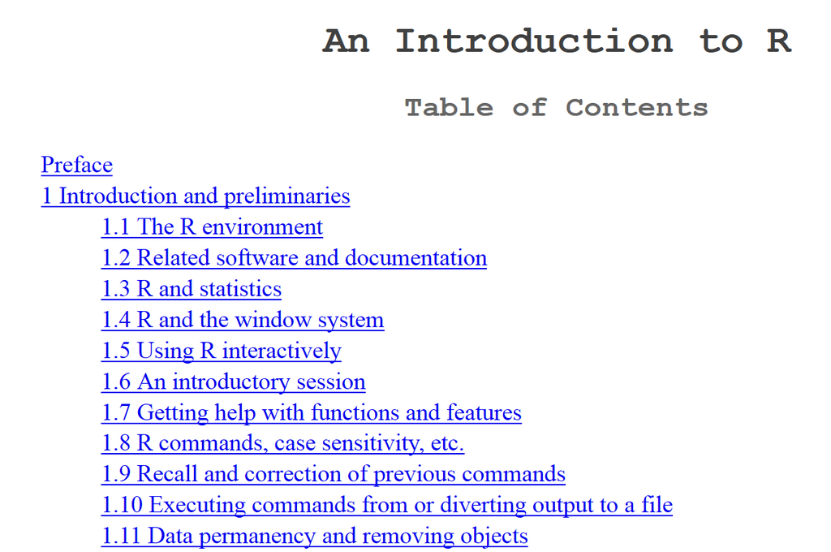

# Aufgabe - Zuweisungen und Funktionen

Erzeugt einen Vektor b mit den Zahlen von 1 bis 5 und berechnet…

1. den Mittelwert
2. die Varianz
3. die Standardabweichung
4. die quadratische Wurzel aus dem Mittelwert

# Verschiedene Datentypen

| Datentyp | Beschreibung | Beispiel |
| --- | --- | --- |
| numeric | ganze und reele Zahlen | `5, 3.462` |
| logical | logische Werte | `FALSE, TRUE` |
| character | Buchstaben und Zeichenfolgen | `"Hallo"` |

Quelle: [R. Münnich und M. Knobelspieß](https://www.uni-trier.de/fileadmin/fb4/prof/VWL/FIN/Oekonometrie/PC-UEbung/Einfuehrung_in_R.pdf) (2007): Einführung in das statistische Programmpaket R

# Verschiedene Datentypen

```r
b <- c(1,2) # numeric
log <- c(T,F) # logical
char <-c("A","b") # character
fac <- as.factor(c(1,2)) # factor
```

Mit `str()` bekommt man den Objekttyp.

```r
str(fac)
```

```
##  Factor w/ 2 levels "1","2": 1 2
```

# Indizieren eines Vektors:

```r
A1 <- c(1,2,3,4)
A1
```

```
## [1] 1 2 3 4
```

```r
A1[1]
```

```
## [1] 1
```

```r
A1[4]
```

```
## [1] 4
```

```r
A1[1:3]
```

```
## [1] 1 2 3
```

```r
A1[-4]
```

```
## [1] 1 2 3
```

# Sequenzen

```r
# Sequenz von 1 bis 10
1:10
```

```
##  [1]  1  2  3  4  5  6  7  8  9 10
```

# Weitere Sequenzen

```r
seq(-2,8,by=1.5)
```

```
## [1] -2.0 -0.5  1.0  2.5  4.0  5.5  7.0
```

```r
a <-seq(3,12,length=12)

b <- seq(to=5,length=12,by=0.2)

d <- 1:10
d <- seq(1,10,1)
d <- seq(length=10,from=1,by=1)
```

# Wiederholungen

```r
# wiederhole 1 10 mal
rep(1,10)
```

```
##  [1] 1 1 1 1 1 1 1 1 1 1
```

```r
rep("A",10)
```

```
##  [1] "A" "A" "A" "A" "A" "A" "A" "A" "A" "A"
```

# Die Funktion paste

```r
?paste
```

```r
paste(1:4)
```

```
## [1] "1" "2" "3" "4"
```

```r
paste("A", 1:6, sep = "")
```

```
## [1] "A1" "A2" "A3" "A4" "A5" "A6"
```

- Ein weiteres Beispiel:

```r
paste0("A", 1:6)
```

```
## [1] "A1" "A2" "A3" "A4" "A5" "A6"
```

# Aufgabe - Vorbereitung

- Prüfen Sie, ob eine Version von R auf Rechner installiert ist.
- Falls dies nicht der Fall ist, laden Sie R runter und installieren Sie R.
- Prüfen Sie, ob Rstudio installiert ist.
- Falls nicht - [Installieren](http://www.rstudio.com/) sie Rstudio.
- Laden Sie die R-Skripte von meinem GitHub-Account
- Erstellen Sie ein erstes Script und finden Sie das Datum mit dem Befehl `date()` und die R-version mit `sessionInfo()` heraus.

```r
date()
```

```
## [1] "Thu Jun 22 20:53:34 2017"
```

[session information not shown]

# Wie bekommt man Hilfe

# Wie bekommt man Hilfe?

- [Um generell Hilfe zu bekommen:](http://itfeature.com/tag/how-to-get-help-in-r)

```r
help.start()
```

- [Online Dokumentation für die meisten Funktionen:](https://www.r-project.org/help.html)

```r
help(name)
```

- Nutze ? um Hilfe zu bekommen.

```r
?mean
```

- example(lm) gibt ein Beispiel für die lineare Regression

```r
example(lm)
```

# Vignetten

- Dokumente zur Veranschaulichung und Erläuterung von Funktionen im Paket

```r
browseVignettes()
```

# Demos

- zu manchem Paketen gibt es Demonstrationen, wie der Code zu verwenden ist

```r
demo()
demo(nlm)
```

# Die Funktion `apropos`

- sucht alles, was mit dem eingegebenen String in Verbindung steht

```r
apropos("lm")
```

```
##  [1] ".__C__anova.glm"      ".__C__anova.glm.null" ".__C__glm"
##  [4] ".__C__glm.null"       ".__C__lm"             ".__C__mlm"
##  [7] ".__C__optionalMethod" ".colMeans"            ".lm.fit"
## [10] "colMeans"             "confint.lm"           "contr.helmert"
## [13] "dummy.coef.lm"        "getAllMethods"        "glm"
## [16] "glm.control"          "glm.fit"              "KalmanForecast"
## [19] "KalmanLike"           "KalmanRun"            "KalmanSmooth"
## [22] "kappa.lm"             "lm"                   "lm.fit"
## [25] "lm.influence"         "lm.wfit"              "model.matrix.lm"
## [28] "nlm"                  "nlminb"               "predict.glm"
## [31] "predict.lm"           "residuals.glm"        "residuals.lm"
## [34] "summary.glm"          "summary.lm"
```

- man kann das auch in Verbindung mit regulären Ausdrücken verwenden

```r
?"regular expression"
```

```r
help.search("^glm")
```

# Suchmaschine für die R-Seite

```r
RSiteSearch("glm")
```

# Nutzung Suchmaschinen

- Ich nutze meistens google
- Tippe:

```
R-project + Was ich schon immer wissen wollte
```

- Das funktioniert natürlich mit jeder Suchmaschine!

# [Stackoverflow](http://stackoverflow.com/)

- Für Fragen zum Programmieren
- [Ist nicht auf R fokussiert, es gibt aber viele Diskussionen zu R](https://stackoverflow.com/tags/r/info)
- Sehr detailierte Diskussionen

[figure not shown]

# [Quick R](http://www.statmethods.net/interface/help.html)

- Immer eine Seite mit Beispielen und Hilfe zu einem Thema
- Beispiel: [Quick R - Getting Help](http://www.statmethods.net/interface/help.html)

# Ein Schummelzettel - Cheatsheet

https://www.rstudio.com/resources/cheatsheets/

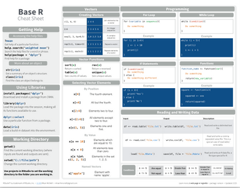

### Weitere Links

- [Eine Liste der wichtigsten R-Befehle](https://www.personality-project.org/r/r.commands.html)

# Modularer Aufbau

# Wo sind die Routinen enthalten

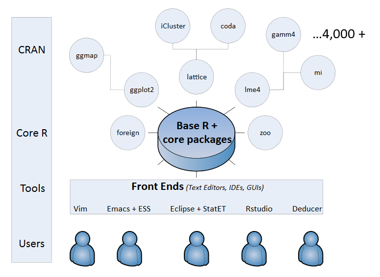

- Viele Funktionen sind im Basis-R enthalten
- Viele spezifische Funktionen sind in zusätzlichen Bibliotheken integriert
- R kann modular erweitert werden durch sog. packages bzw. libraries
- Auf CRAN werden die wichtigsten packages gehostet (im Moment 10430)
- Weitergehende Pakete finden sich z.B. bei bioconductor

```r
install.packages("lme4")

library(lme4)
```

# Installation von Paketen mit RStudio

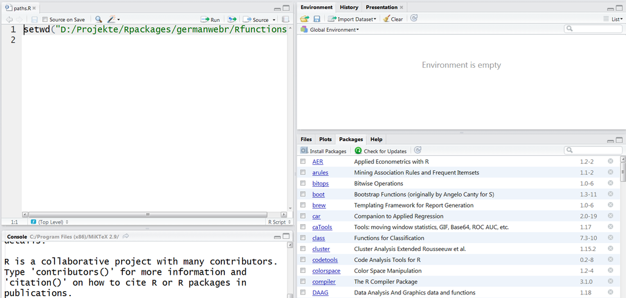

# Vorhandene Pakete und Installation

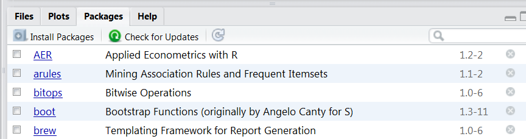

# Übersicht viele nützliche Pakete:

- Luhmann - [Tabelle mit vielen nützlichen Paketen](http://www.beltz.de/fileadmin/beltz/downloads/OnlinematerialienPVU/28090_Luhmann/Verwendete%20Pakete.pdf)

Weitere interessante Pakete:

- Paket für den Import/Export - [foreign](http://cran.r-project.org/web/packages/foreign/foreign.pdf)
- [Pakete für Survey Sampling](http://iase-web.org/documents/papers/icots8/ICOTS8_4J1_TILLE.pdf)
- `xtable` Paket für die Integration von Latex und R ([xtable Galerie](http://cran.r-project.org/web/packages/xtable/vignettes/xtableGallery.pdf))
- [Paket zur Erzeugung von Dummies](http://cran.r-project.org/web/packages/dummies/dummies.pdf)
- [Multivariate Normalverteilung](http://cran.r-project.org/web/packages/mvtnorm/index.html)
- [Paket für Karten](http://www.r-bloggers.com/tag/maptools/)

# Pakete installieren

### Pakete von CRAN Server installieren

```r
install.packages("lme4")
```

### Pakete von Bioconductor Server installieren

```r
source("https://bioconductor.org/biocLite.R")
biocLite(c("GenomicFeatures", "AnnotationDbi"))
```

### Pakete von Github installieren

```r
install.packages("devtools")
library(devtools)

install_github("hadley/ggplot2")
```

# Wie bekomme ich einen Überblick

- [Pakete entdecken, die neulich auf CRAN hochgeladen wurden](https://mran.microsoft.com/packages/)
- [Pakete die in letzter Zeit von CRAN heruntergeladen wurden](https://gallery.shinyapps.io/cran-gauge/)
- [Quick-list nützlicher Pakete](https://support.rstudio.com/hc/en-us/articles/201057987-Quick-list-of-useful-R-packages)
- [Beste Pakete für Datenbearbeitung und Analyse](http://www.computerworld.com/article/2921176/business-intelligence/great-r-packages-for-data-import-wrangling-visualization.html)
- [Die 50 meist genutzten Pakete](https://www.r-bloggers.com/the-50-most-used-r-packages/)

# CRAN Task Views

- Zu einigen Themen sind alle Möglichkeiten in R zusammengestellt. ([Übersicht der Task Views](https://cran.r-project.org/web/views/))
- Zur Zeit gibt es 35 Task Views
- [Alle Pakete eines Task Views können mit folgendem Befehl installiert werden:](https://mran.microsoft.com/rpackages/)

```r
install.packages("ctv")
library("ctv")
install.views("Bayesian")
```

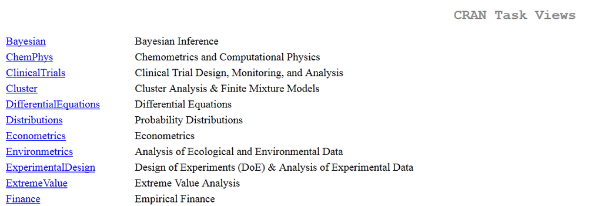

# Aufgabe - Zusatzpakete

Gehen Sie auf https://cran.r-project.org/ und suchen Sie in dem Bereich, wo die Pakete vorgestellt werden, nach Paketen,…

- die für die deskriptive Datenanalyse geeignet sind.
- um Regressionen zu berechnen
- um fremde Datensätze einzulesen (z.B. SPSS-Daten)
- um mit großen Datenmengen umzugehen

# Datenimport

# Datenimport

[figure not shown]

# Dateiformate in R

- Von R werden quelloffene, nicht-proprietäre Formate bevorzugt
- Es können aber auch Formate von anderen Statistik Software Paketen eingelesen werden
- R-user speichern Objekte gerne in sog. Workspaces ab
- Auch hier jedoch gilt: (fast) alles andere ist möglich

# Formate - base package

R unterstützt von Haus aus schon einige wichtige Formate:

- CSV (Comma Separated Values): `read.csv()`
- FWF (Fixed With Format): `read.fwf()`
- Tab-getrennte Werte: `read.delim()`

```r
gpanel <- read.csv2("ZA5666_d_gesis_panel_campus_file_b_2014.csv")
head(gpanel)
```

# Der Arbeitsspeicher

So findet man heraus, in welchem Verzeichnis man sich gerade befindet

```r
getwd()
```

So kann man das Arbeitsverzeichnis ändern:

Man erzeugt ein Objekt in dem man den Pfad abspeichert:

```r
main.path <- "C:/" # Beispiel für Windows
main.path <- "/users/Name/" # Beispiel für Mac
main.path <- "/home/user/" # Beispiel für Linux
```

Und ändert dann den Pfad mit setwd()

```r
setwd(main.path)
```

Bei Windows ist es wichtig Slashs anstelle von Backslashs zu verwenden.

# Alternative - Arbeitsspeicher

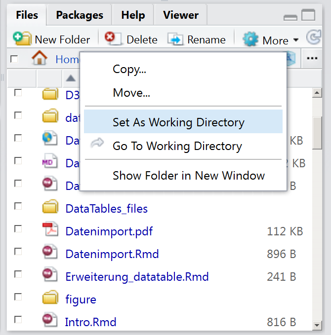

# Import von Excel-Daten

- `library(foreign)` ist für den Import von fremden Datenformaten nötig
- Wenn Excel-Daten vorliegen - als .csv abspeichern
- Dann kann `read.csv()` genutzt werden um die Daten einzulesen.
- Bei Deutschen Daten kann es sein, dass man `read.csv2()` wegen der Komma-Separierung braucht.

```r
library(foreign)
?read.csv
?read.csv2
```

# CSV Dateien einlesen

Zunächst muss das Arbeitsverzeichnis gesetzt werden, in dem sich die Daten befinden:

```r
Dat <- read.csv("schuldaten_export.csv")
```

Wenn es sich um Deutsche Daten handelt:

```r
Dat <- read.csv2("schuldaten_export.csv")
```

# SPSS Dateien einlesen

Dateien können auch direkt aus dem Internet geladen werden:

```r
link<- "http://www.statistik.at/web_de/static/
mz_2013_sds_-_datensatz_080469.sav"

?read.spss
Dat <- read.spss(link,to.data.frame=T)
```

# stata Dateien einlesen

```r
MZ02 <- read.dta("MZ02.dta")
```

- Einführung in Import mit R ([is.R](http://is-r.tumblr.com/post/37181850668/reading-writing-stata-dta-files-with-foreign))

# [Das Paket `rio`](https://cran.r-project.org/web/packages/rio/vignettes/rio.html)

```r
install.packages("rio")
```

```r
library("rio")
x <- import("mtcars.csv")
y <- import("mtcars.rds")
z <- import("mtcars.dta")
```

- [rio: A Swiss-Army Knife for Data I/O](https://cran.r-project.org/web/packages/rio/README.html)

# Datenmanagement ähnlich wie in SPSS oder Stata

```r
install.packages("Rz")
library(Rz)
```

# [Weitere Alternative Rcmdr](https://cran.r-project.org/web/packages/Rcmdr/index.html)

```r
install.packages("Rcmdr")
```

- [Funktioniert auch mit Rstudio](http://www.rcommander.com/)

```r
library(Rcmdr)
```

[figure not shown]

# Datenaufbereitung

# Data Frames

Beispieldaten einlesen:

```r
library(foreign)
dat <- read.dta("https://github.com/Japhilko/RSocialScience/blob/master/data/GPanel.dta")
typeof(dat)
```

```r
Daten <- data.frame(dat)
```

Anzahl der Zeilen/Spalten herausfinden

```r
nrow(Daten) # Zeilen
ncol(Daten) # Spalten
```

# Indizieren

Indizieren eines dataframe:

```r
Daten[1,1]
Daten[2,]
Daten[,1]
Daten[,1:2]
```

# Logische Operatoren

```r
# Ist 1 größer als 2?
1>2
1<2

1==2
```

# Operatoren um Subset für Datensatz zu bekommen

Diese Operatoren eignen sich gut um Datensätze einzuschränken

```r
Dauer <- as.numeric(Daten$bazq020a)
head(Daten[Dauer>20,])
```

# Datensätze einschränken

```r
SEX <- Daten$a11d054a

Daten[SEX=="Männlich",]
# gleiches Ergebnis:
Daten[SEX!="Weiblich",]
```

# Weitere wichtige Optionen

```r
# Ergebnis in ein Objekt speichern
subDat <- Daten[Dauer>20,]
```

```r
# mehrere Bedingeungen können mit
# & verknüpft werden:
Daten[Dauer>18 & SEX=="Männlich",]
```

# Die Nutzung einer Sequenz

```r
Daten[1:3,]
```

# [Variablen Labels](https://stackoverflow.com/questions/2151147/using-stata-variable-labels-in-r)

```r
library(foreign)
dat <- read.dta("https://github.com/Japhilko/RSocialScience/blob/master/data/GPanel.dta?raw=true")
```

```r
var.labels <- attr(dat,"var.labels")
```

# Ein Überblick

```r
nrow(dat)
ncol(dat)
```

```r
head(dat)
```

# Indizieren

- Das Dollarzeichen kann man nutzen um einzelne Spalten anzusprechen

```r
head(dat$a11c019a)

dat$a11c019a[1:10]
```

- Man kann auch Zahlen nutzen um auf die Spalten zuzugreifen

```r
head(dat[,1])
```

# Datentypen

```r
# as.numeric()
```

# [Rekodieren](https://www.r-bloggers.com/recoding-variables-in-r-pedagogic-considerations/)

```r
library(car)
```

```r
?recode
```

# Exkurs - Labels wie verwenden

```r
library("forcats")
```

```r
browseVignettes()
```

```r
library(tibble)

gpanel1 <- as_tibble(Daten)

head(gpanel1)
```

# Schleifen

```r
erg <- vector()

for (i in 1:ncol(dat)){
  erg[i] <- length(table(dat[,i]))
}
```

# Fehlende Werte

```r
Daten$bazq020a[Daten$bazq020a==-99] <- NA
```

- [Quick-R zu fehlenden Werten](http://www.statmethods.net/input/missingdata.html)
- [Fehlende Werte rekodieren](http://uc-r.github.io/na_recode)

# Datenexport

# Basisgrafiken

# Datenanalyse

# Grafiken und Zusammenhang

# Das lattice Paket

# ggplot und ggmap

# Die lineare Regression

# Die logistische Regression

# Mehrebenenmodelle

# Allgemein zur Versionsverwaltung

# R und Git

# Word Dokumente mit R erstellen